# Multiple Regression: Diagnostics - Week 10, Lecture 1

Author

Dr. Seals

**Recall the airline data from last week; we modeled revenue as a function of distance and population. The data are given here: [Google Sheet](https://docs.google.com/spreadsheets/d/10ZN0jMYdVsG2ucIJFSTquVRW916Jj-JmZIGQuqSQhy0/edit?usp=sharing).**

```r
library(tidyverse)
library(gsheet)
data <- as_tibble(gsheet2tbl("https://docs.google.com/spreadsheets/d/10ZN0jMYdVsG2ucIJFSTquVRW916Jj-JmZIGQuqSQhy0/edit?usp=sharing"))
```

**1. Summarize your findings from last week. What was the resulting model, which were significant predictors of revenue (no formal hypothesis test needed - just state with appropriate evidence)? Also include the graph constructed to visualize the model.**

```r
m1 <- lm(Revenue ~ Distance + Population, data = data)
```

**2. Determine if there are outliers in this model. Be sure to count and list the observations that are outliers.**

```r
data <- data %>% mutate(outlier = abs(rstandard(m1))>2.5)
data %>% count(outlier)
```

```
# A tibble: 2 × 2
  outlier     n
  <lgl>   <int>
1 FALSE      21
2 TRUE        1
```

```r
data2 <- data %>% filter(outlier == TRUE)
head(data2)
```

```
# A tibble: 1 × 5
  Airport Revenue Distance Population outlier
    <dbl>   <dbl>    <dbl>      <dbl> <lgl>
1      22     200      340         75 TRUE
```

Airport 22 is the outlier.

**3. Determine if there are any influence and leverage points in this model. Be sure to count and list the observations that are considered influential and leverage.**

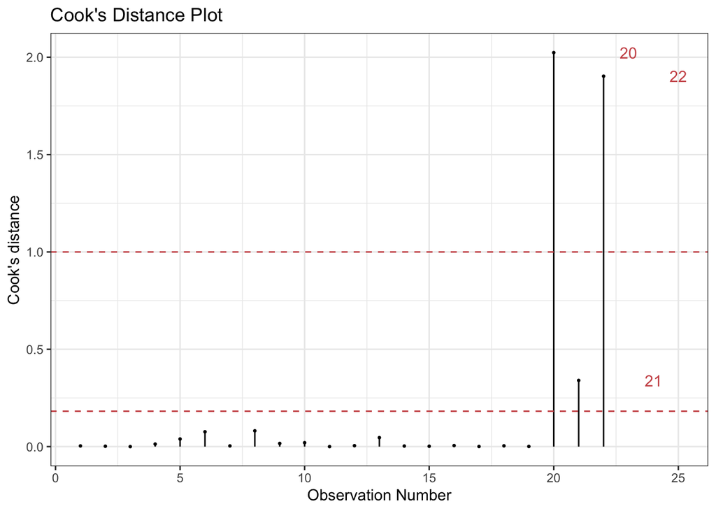

```r
library(lindia)
gg_cooksd(m1) + theme_bw()
```

**4. Is there evidence of multicollinearity?**

```r
library(car)
vif(m1)
```

```
  Distance Population
  1.060931   1.060931
```

No, multicollinearity is not present.

**5. Perform a sensitivity analysis: remove the data points identified as potential offenders in Q2 and Q3 and reconstruct the model. Be sure to state the resulting model.**

```r
data3 <- data %>% filter(!Airport %in% c(20, 22))
tail(data3, n=3)
```

```
# A tibble: 3 × 5
  Airport Revenue Distance Population outlier
    <dbl>   <dbl>    <dbl>      <dbl> <lgl>
1      18     233      220         60 FALSE
2      19     234      170         60 FALSE
3      21     340      290         70 FALSE
```

We eliminated airports 20 and 22.

```r
m2 <- lm(Revenue ~ Distance + Population, data = data3)
summary(m2)
```

```
Call:
lm(formula = Revenue ~ Distance + Population, data = data3)

Residuals:
   Min     1Q Median     3Q    Max
-29.36 -17.61  -7.03  14.87  49.36

Coefficients:
            Estimate Std. Error t value Pr(>|t|)
(Intercept)  99.9119    45.7114   2.186  0.04312 *
Distance      0.4840     0.1414   3.422  0.00325 **
Population    0.8869     0.3731   2.377  0.02946 *
---
Signif. codes:  0 '***' 0.001 '**' 0.01 '*' 0.05 '.' 0.1 ' ' 1

Residual standard error: 25.54 on 17 degrees of freedom
Multiple R-squared:  0.4473,    Adjusted R-squared:  0.3822
F-statistic: 6.878 on 2 and 17 DF,  p-value: 0.006477
```

$$\hat{\text{revenue}} = 99.91 + 0.48 \text{ distance} + 0.89 \text{ population}$$

**6. Using the model in Q5, are there any significant predictors of revenue?**

Yes, both distance and population are significant predictors of revenue (*p* = 0.003 and *p* = 0.029, respectively).

**7. Reconstruct the data visualization from last week, but using the new model’s results.**

**8. Put the graphs from last week and Q7 side by side (hint: use `ggpubr`).**

**9. Compare and contrast the modeling results and the graphs that are side by side in Q8.**

**10. Why do you think I assigned this particular dataset for analysis? What are you taking away from this assignment?**